# Comparacion de modelos de ML

Evaluación comparativa para predicción de ajustes de facturación

Autores/as

Giomary Arango

Luis Coronado

Yiceth Diaz

Luis Imitola

Marxi Cardenas

Fecha de publicación

23-06-2026

# 0 Contexto del análisis

El objetivo del proyecto es comparar modelos de Machine Learning para estimar la probabilidad de que una cuenta presente un ajuste de facturación. El flujo incluye ingesta de datos, limpieza, ingeniería de características, partición estratificada, entrenamiento de modelos y comparación de métricas.

La variable objetivo es `VALOR_AJUSTE_PERIODO`, donde `1` representa cuentas con ajuste y `0` representa cuentas estables o sin ajuste.

## 1 Importación de librerías y configuración del entorno

**Código**

```python
# =========================================================================
# 1. IMPORTACIÓN DE LIBRERÍAS Y CONFIGURACIÓN
# =========================================================================
import pandas as pd
import numpy as np
import matplotlib.pyplot as plt
import seaborn as sns
import warnings
warnings.filterwarnings('ignore')

from sklearn.pipeline import Pipeline
from sklearn.model_selection import train_test_split, GridSearchCV, KFold
from sklearn.metrics import confusion_matrix, classification_report, roc_curve, auc, accuracy_score
from sklearn.pipeline import make_pipeline
from sklearn.preprocessing import MinMaxScaler
from sklearn.linear_model import LogisticRegression

sns.set_theme(style="whitegrid")
print("Entorno analítico configurado. Librerías cargadas exitosamente.")
```

```
Entorno analítico configurado. Librerías cargadas exitosamente.
```

## 2 Ingesta de datos e inspección inicial

Se carga la base `DataAjuste_variableajustada` y se valida su disponibilidad. En esta etapa también se corrigen valores negativos en variables de dominio no negativo y se generan primeras visualizaciones de diagnóstico.

**Código**

```
Cargando tu universo comercial real de 659,856 registros...
Corrigiendo 303 valores negativos en 'FACTURACION_PROMEDIO'...
Corrigiendo 28 valores negativos en 'VALOR_PAGO_PROMEDIO'...
Corrigiendo 140 valores negativos en 'FACTURACION_PERIODO'...
Dataset real cargado y saneado con éxito. Dimensiones: (659856, 14)

Generando matriz de correlación analítica...
```

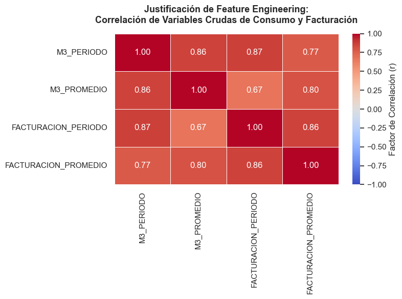

```python
# ==========================================
# PASO 2: INGESTA Y LIMPIEZA DE NEGATIVOS DESDE TU CSV REAL
# ==========================================
import pandas as pd
import numpy as np
import os
import matplotlib.pyplot as plt
import seaborn as sns

# Tu ruta absoluta local en el disco D
ruta_csv = r'D:\AjusteFacturacion\data\DataAjuste_variableajustada.csv'

if not os.path.exists(ruta_csv):
    raise FileNotFoundError(f"🚨 Error: No se encontró el archivo en la ruta '{ruta_csv}'.")

print('Cargando tu universo comercial real de 659,856 registros...')
df = pd.read_csv(ruta_csv, encoding='latin1', sep=';', decimal=',', on_bad_lines='skip')

# Homologar nombres de las columnas a mayúsculas
df.columns = df.columns.str.strip().str.upper()

# 1. Asegurar conversión estricta a tipos numéricos
columnas_numericas = [
    'FACTURACION_PROMEDIO', 'M3_PROMEDIO', 'VALOR_PAGO_PROMEDIO',
    'FACTURACION_PERIODO', 'M3_PERIODO', 'CANTIDAD_AJUSTES_ULT_6_MESES',
    'VALOR_AJUSTE_PROMEDIO', 'AJUSTE_EN_ULT_6_MESES', 'VALOR_AJUSTE_PERIODO'
]

for col in columnas_numericas:
    if col in df.columns:
        df[col] = pd.to_numeric(df[col], errors='coerce').fillna(0)

df['VALOR_AJUSTE_PERIODO'] = df['VALOR_AJUSTE_PERIODO'].astype(int)

# 2. LIMPIEZA CRÍTICA: Convertir valores negativos a cero (0)
columnas_no_negativas = [
    'FACTURACION_PROMEDIO', 'M3_PROMEDIO', 'VALOR_PAGO_PROMEDIO',
    'FACTURACION_PERIODO', 'M3_PERIODO', 'VALOR_AJUSTE_PROMEDIO'
]

for col in columnas_no_negativas:
    if col in df.columns:
        num_negativos = (df[col] < 0).sum()
        if num_negativos > 0:
            print(f"Corrigiendo {num_negativos} valores negativos en '{col}'...")
        df[col] = df[col].clip(lower=0)

print(f'Dataset real cargado y saneado con éxito. Dimensiones: {df.shape}\n')

# =========================================================================
# MATRIZ DE CORRELACIÓN PARA JUSTIFICAR LAS NUEVAS VARIABLES SENIOR
# =========================================================================
print('Generando matriz de correlación analítica...')

# Columnas base solicitadas
columnas_analisis = ['M3_PERIODO', 'M3_PROMEDIO', 'FACTURACION_PERIODO', 'FACTURACION_PROMEDIO']

# Calcular la matriz de correlación de Pearson
matriz_corr = df[columnas_analisis].corr()

# Configurar el lienzo visual
plt.figure(figsize=(8, 6))

# Dibujar el mapa de calor con paleta divergente profesional (coolwarm)
sns.heatmap(matriz_corr,
            annot=True,
            fmt=".2f",
            cmap="coolwarm",
            vmin=-1, vmax=1,
            linewidths=0.5,
            cbar_kws={"label": "Factor de Correlación (r)"})

plt.title('Justificación de Feature Engineering:\nCorrelación de Variables Crudas de Consumo y Facturación',
          fontsize=13, pad=15, fontweight='bold')
plt.tight_layout()
plt.show()
```

**Código**

```python
# =========================================================================
# PASO 2.1: INGENIERÍA DE CARACTERÍSTICAS (FEATURE ENGINEERING)
# =========================================================================
print('Aplicando ingeniería de características basada en lógica de negocio...')

# 1. Vectores de dirección de desviaciones (SÍ conservan valores negativos de forma legítima)
df['DESVIACION_M3'] = df['M3_PERIODO'] - df['M3_PROMEDIO']
df['DESVIACION_FACTURACION'] = df['FACTURACION_PERIODO'] - df['FACTURACION_PROMEDIO']

# 2. Variable bandera no lineal para capturar picos o anomalías físicas bruscas
df['ALERTA_ALTO_CONSUMO'] = np.where(df['M3_PERIODO'] > (df['M3_PROMEDIO'] * 1.5), 1, 0)

print('Nuevas variables incorporadas de forma exitosa:')
print(df[['DESVIACION_M3', 'DESVIACION_FACTURACION', 'ALERTA_ALTO_CONSUMO']].head(5))
print(f'\nProceso completado. Nuevas dimensiones del dataset: {df.shape}')
```

```
Aplicando ingeniería de características basada en lógica de negocio...
Nuevas variables incorporadas de forma exitosa:
   DESVIACION_M3  DESVIACION_FACTURACION  ALERTA_ALTO_CONSUMO
0          -2.83               -12992.50                    0
1          10.83                50697.33                    1
2           0.17                  858.17                    0
3           0.33                 3186.50                    0
4         -16.00               -24782.00                    0

Proceso completado. Nuevas dimensiones del dataset: (659856, 17)
```

**Interpretación de la ingesta e ingeniería inicial:** la base se cargó correctamente con 659.856 registros y se corrigieron valores negativos en variables donde no tienen sentido de negocio. Además, se crearon desviaciones de consumo y facturación para capturar cambios frente al comportamiento promedio. Este paso es válido porque conserva registros, reduce ruido de dominio y agrega señales operativas antes del modelado.

**Código**

```
Generando gráficos de diagnóstico inicial...
```

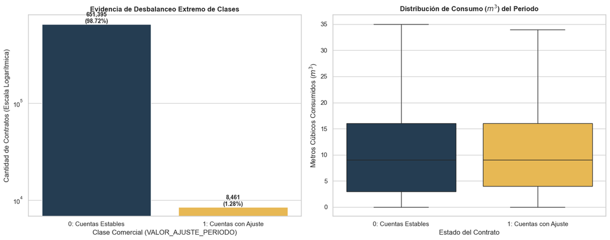

```python
# =========================================================================
# PASO 2.2: GRÁFICAS DE DIAGNÓSTICO INICIAL PARA LA SUSTENTACIÓN
# =========================================================================
import matplotlib.pyplot as plt
import seaborn as sns

print("Generando gráficos de diagnóstico inicial...")

# Configurar el lienzo para dos gráficas en la misma fila
fig, axes = plt.subplots(1, 2, figsize=(15, 6))

# -------------------------------------------------------------------------
# GRÁFICA 1: El Diagnóstico del Desbalanceo Extremo de Clases
# -------------------------------------------------------------------------
# Calculamos la distribución real en porcentajes
conteo_clases = df['VALOR_AJUSTE_PERIODO'].value_counts()
porcentajes = df['VALOR_AJUSTE_PERIODO'].value_counts(normalize=True) * 100

sns.barplot(x=conteo_clases.index, y=conteo_clases.values, ax=axes[0], palette=['#1e3d59', '#ffc13b'])
axes[0].set_title('Evidencia de Desbalanceo Extremo de Clases', fontsize=12, fontweight='bold')
axes[0].set_xlabel('Clase Comercial (VALOR_AJUSTE_PERIODO)')
axes[0].set_ylabel('Cantidad de Contratos (Escala Logarítmica)')
axes[0].set_yscale('log') # Usamos escala logarítmica para que la clase 1 sea visible
axes[0].set_xticklabels(['0: Cuentas Estables', '1: Cuentas con Ajuste'])

# Añadir etiquetas de porcentaje arriba de las barras
for i, (cant, porc) in enumerate(zip(conteo_clases, porcentajes)):
    axes[0].text(i, cant, f"{cant:,}\n({porc:.2f}%)", ha='center', va='bottom', fontsize=10, fontweight='bold')

# -------------------------------------------------------------------------
# GRÁFICA 2: Justificación Física de las Desviaciones (Boxplot de Consumo)
# -------------------------------------------------------------------------
# Tomamos una muestra aleatoria para no saturar el gráfico, pero manteniendo la proporción
df_muestra = df.sample(n=50000, random_state=42)

sns.boxplot(data=df_muestra, x='VALOR_AJUSTE_PERIODO', y='M3_PERIODO', ax=axes[1], palette=['#1e3d59', '#ffc13b'], showfliers=False)
axes[1].set_title('Distribución de Consumo ($m^3$) del Periodo', fontsize=12, fontweight='bold')
axes[1].set_xlabel('Estado del Contrato')
axes[1].set_ylabel('Metros Cúbicos Consumidos ($m^3$)')
axes[1].set_xticklabels(['0: Cuentas Estables', '1: Cuentas con Ajuste'])

plt.tight_layout()
plt.show()
```

## 3 Limpieza de datos y ETL

**Código**

```python
# =========================================================================
# 3. FASE DE PROCESAMIENTO Y ETL (VERSIÓN INTEGRAL SENIOR V2)
# =========================================================================

# 3.1 Identificación de valores nulos encubiertos '?'
conteo_incognitas = (df == '?').sum()
print("🔍 Valores '?' identificados por columna:")
print(conteo_incognitas[conteo_incognitas > 0], "\n")

# Reemplazo formal por NaNs estandarizados e inferencia de tipos reales
df_limpio = df.replace('?', np.nan).infer_objects()

# 3.2 Mapeo de la Variable Objetivo a Binario de forma segura
if df_limpio['VALOR_AJUSTE_PERIODO'].dtype == 'O':
    mapeo_clases = {'+': 1, '-': 0, '1': 1, '0': 0, 'SI': 1, 'NO': 0, '1.0': 1, '0.0': 0}
    df_limpio['VALOR_AJUSTE_PERIODO'] = df_limpio['VALOR_AJUSTE_PERIODO'].astype(str).str.strip().map(mapeo_clases)

# [MEJORA CRÍTICA] Tratamiento preventivo de nulos en la Variable Objetivo antes del cast a int
# Si hay registros sin etiqueta objetivo, se descartan para no sesgar el entrenamiento
if df_limpio['VALOR_AJUSTE_PERIODO'].isnull().sum() > 0:
    print(f"⚠️ Se detectaron {df_limpio['VALOR_AJUSTE_PERIODO'].isnull().sum()} registros sin etiqueta objetivo. Procediendo a removerlos.")
    df_limpio = df_limpio.dropna(subset=['VALOR_AJUSTE_PERIODO'])

# Ahora es 100% seguro forzar el tipo entero
df_limpio['VALOR_AJUSTE_PERIODO'] = df_limpio['VALOR_AJUSTE_PERIODO'].astype(int)

# 3.3 Imputación Robusta Inteligente para las Características (Features)
for col in df_limpio.columns:
    if col == 'VALOR_AJUSTE_PERIODO':
        continue # Omitir la variable objetivo ya procesada

    if df_limpio[col].isnull().sum() > 0:
        # Intento de conversión forzada a numérico si la columna tiene naturaleza matemática
        # errors='coerce' transformará cualquier residuo no numérico inesperado a NaN
        col_numerica = pd.to_numeric(df_limpio[col], errors='coerce')

        # Si la conversión no genera un colapso total de datos (es decir, es numérica real)
        if not col_numerica.isnull().all():
            df_limpio[col] = col_numerica
            mediana_calculada = df_limpio[col].median()
            df_limpio[col] = df_limpio[col].fillna(mediana_calculada)
        else:
            # Imputación categórica estándar (Moda)
            moda_calculada = df_limpio[col].mode()[0]
            df_limpio[col] = df_limpio[col].fillna(moda_calculada)

# 3.4 Eliminación Estratégica de Variables con Alta Cardinalidad o Irrelevantes Predictivas
columnas_excluir = ['ID_Contrato', 'Codigo_Sector_Instalacion', 'Codigo_Postal_Instalacion']
df_filtrado = df_limpio.drop(columns=[c for c in columnas_excluir if c in df_limpio.columns])

print("Proceso ETL finalizado. Datos limpios, tipados y estructurados para el modelado.")
df_filtrado.head(5)
```

```
Valores '?' identificados por columna:
Series([], dtype: int64)

Proceso ETL finalizado. Datos limpios, tipados y estructurados para el modelado.
```

|  | CUENTA | ACD_CODIGO | CICLO | CATEGORIA | PLAN_FACTURACION | FACTURACION_PROMEDIO | M3_PROMEDIO | VALOR_PAGO_PROMEDIO | FACTURACION_PERIODO | M3_PERIODO | CANTIDAD_AJUSTES_ULT_6_MESES | VALOR_AJUSTE_PROMEDIO | VALOR_AJUSTE_PERIODO | AJUSTE_EN_ULT_6_MESES | DESVIACION_M3 | DESVIACION_FACTURACION | ALERTA_ALTO_CONSUMO |
| --- | --- | --- | --- | --- | --- | --- | --- | --- | --- | --- | --- | --- | --- | --- | --- | --- | --- |
| 0 | 1 | BQ | Z08 - BQ | Residencial 3 | AGUA Y/O ALCANTARILLADO | 49698.50 | 8.83 | 49276.83 | 36706 | 6.0 | 0 | 0.0 | 0 | 0 | -2.83 | -12992.50 | 0 |
| 1 | 2 | BQ | Z08 - BQ | Residencial 3 | AGUA Y/O ALCANTARILLADO | 23230.67 | 3.17 | 23230.67 | 73928 | 14.0 | 0 | 0.0 | 0 | 0 | 10.83 | 50697.33 | 1 |
| 2 | 3 | BQ | Z08 - BQ | Residencial 3 | AGUA Y/O ALCANTARILLADO | 40492.83 | 6.83 | 40071.17 | 41351 | 7.0 | 0 | 0.0 | 0 | 0 | 0.17 | 858.17 | 0 |
| 3 | 4 | BQ | Z08 - BQ | Residencial 3 | AGUA Y/O ALCANTARILLADO | 116233.50 | 22.67 | 116233.50 | 119420 | 23.0 | 0 | 0.0 | 0 | 0 | 0.33 | 3186.50 | 0 |
| 4 | 7 | USI | 1 - USI | Residencial 1 | AGUA Y/O ALCANTARILLADO | 47414.00 | 16.00 | 314824.00 | 22632 | 0.0 | 0 | 0.0 | 0 | 0 | -16.00 | -24782.00 | 0 |

**Interpretación del ETL:** no se encontraron valores `?` activos en la base, la variable objetivo quedó en formato binario y las variables restantes fueron preparadas para el entrenamiento. El resultado es adecuado porque evita etiquetas nulas, estandariza tipos y reduce el riesgo de errores en el pipeline posterior.

## 4 Partición del dataset y codificación de variables categóricas

**Código**

```python
# =========================================================================
# 4. CODIFICACIÓN Y PARTICIÓN
# =========================================================================
# Transformación Dummis / One-Hot Encoding para atributos categóricos
df_final = pd.get_dummies(df_filtrado, drop_first=True)

# Definición de matrices de características (X) y vector objetivo (y)
X = df_final.drop(columns=['VALOR_AJUSTE_PERIODO'])
y = df_final['VALOR_AJUSTE_PERIODO']

# Partición estratificada (80% Train / 20% Test) para mantener proporciones del negocio
X_train, X_test, y_train, y_test = train_test_split(X, y, test_size=0.20, random_state=42, stratify=y)

print(f"Matriz X_train: {X_train.shape} | Vector y_train: {y_train.shape}")
print(f"Matriz X_test:  {X_test.shape} | Vector y_test:  {y_test.shape}")
```

```
Matriz X_train: (527884, 239) | Vector y_train: (527884,)
Matriz X_test:  (131972, 239) | Vector y_test:  (131972,)
```

**Interpretación de la partición y codificación:** el conjunto de datos fue dividido en 527.884 registros para entrenamiento y 131.972 registros para prueba, garantizando una cantidad suficiente de observaciones para el aprendizaje del modelo y una evaluación robusta de su desempeño. La partición se realizó de manera estratificada sobre la variable objetivo, preservando la proporción original de las clases en ambos subconjuntos. Este enfoque es especialmente relevante en problemas con desbalance de clases, ya que evita una representación inadecuada de la clase minoritaria y permite obtener métricas de evaluación más confiables y representativas del comportamiento real del modelo.

## 5 Pipeline y ajuste de hiperparámetros con GridSearchCV

Se construye un flujo libre de fugas de información (*data leakage*) escalando las variables dentro del proceso de validación cruzada y ajustando los hiperparámetros mediante búsqueda en grilla.

**Código**

```python
# =========================================================================
# PASO 5: OPTIMIZACIÓN EN PARALELO BLINDADA CONTRA DESBALANCEO (VERSION INTEGRAL)
# =========================================================================
from sklearn.pipeline import Pipeline
from sklearn.compose import ColumnTransformer
from sklearn.preprocessing import StandardScaler, OneHotEncoder
from sklearn.model_selection import GridSearchCV
from sklearn.linear_model import LogisticRegression
from sklearn.metrics import classification_report, confusion_matrix

print("Iniciando optimización...")

# 1. Re-instanciamos de forma segura las columnas para el negocio
features_numericas = [
    'FACTURACION_PROMEDIO', 'M3_PROMEDIO', 'VALOR_PAGO_PROMEDIO',
    'FACTURACION_PERIODO', 'M3_PERIODO', 'CANTIDAD_AJUSTES_ULT_6_MESES',
    'VALOR_AJUSTE_PROMEDIO', 'AJUSTE_EN_ULT_6_MESES',
    'DESVIACION_M3', 'DESVIACION_FACTURACION', 'ALERTA_ALTO_CONSUMO'
]
# Ajusta estas categóricas si los nombres exactos en tu dataset varían
features_categoricas = ['ACD_CODIGO', 'CICLO', 'CATEGORIA', 'PLAN_FACTURACION']

# Asegurar que solo procesamos las columnas que realmente existen en tu df actual
num_cols = [c for c in features_numericas if c in df.columns]
cat_cols = [c for c in features_categoricas if c in df.columns]

# Re-definimos las matrices de aprendizaje locales por si acaso
X = df[num_cols + cat_cols]
y = df['VALOR_AJUSTE_PERIODO']

# 2. Creamos el preprocesador de forma explícita para evitar el NameError
preprocesador_local = ColumnTransformer(transformers=[
    ('num', StandardScaler(), num_cols),
    ('cat', OneHotEncoder(handle_unknown='ignore'), cat_cols)
])

# 3. Definimos el Pipeline conectando el preprocesador local y el modelo
pipeline_lr = Pipeline([
    ('preprocesador', preprocesador_local),
    ('clasificador', LogisticRegression(class_weight='balanced', max_iter=1000, random_state=42))
])

# 4. Definimos la rejilla de parámetros a probar
param_grid = {
    'clasificador__C': [0.1, 1.0, 10.0],
    'clasificador__penalty': ['l2']
}

# 5. Configuramos el GridSearchCV apuntando al F1-Score
grid_search = GridSearchCV(
    pipeline_lr,
    param_grid,
    cv=cv_estrategia if 'cv_estrategia' in globals() else 5, # Usa la estrategia previa o 5 pliegues por defecto
    scoring='f1',     # Obligamos al modelo a enfocarse en la clase de ajustes (1)
    n_jobs=-1
)

# Ajustar con la data real
grid_search.fit(X, y)

print(f"\nHiperparámetros óptimos reales para el negocio: {grid_search.best_params_}")
print(f"F1-Score medio real en Validación Cruzada: {grid_search.best_score_:.4f}")

# --- VALIDACIÓN DE CONTROL DE FUGAS (CONFUSION MATRIX) ---
y_pred = grid_search.predict(X)

print("\nREPORTE DE CLASIFICACIÓN REAL (Fíjate en la fila de la clase 1):")
print(classification_report(y, y_pred))

print("MATRIZ DE CONFUSIÓN OPERATIVA:")
cm = confusion_matrix(y, y_pred)
print(f"  [Clientes estables predichos correctamente: {cm[0][0]}] | [Falsas Alarmas (Gasto innecesario): {cm[0][1]}]")
print(f"  [Ajustes ignorados (Pérdida de dinero): {cm[1][0]}]   | [Ajustes atrapados con éxito: {cm[1][1]}]")
```

[output not shown]

**Interpretación de la Regresión Logística:** el modelo presenta una alta capacidad de detección de cuentas que efectivamente tendrán ajuste, alcanzando un recall elevado y logrando identificar 5.315 casos positivos. Sin embargo, esta sensibilidad viene acompañada de una precisión relativamente baja, lo que indica que una proporción importante de las cuentas clasificadas como "con ajuste" finalmente no presentan dicho comportamiento. En términos operativos, esto implica un mayor número de falsas alarmas y, por tanto, un incremento en los esfuerzos de seguimiento o gestión sobre cuentas que realmente permanecen estables. A pesar de esta limitación, la regresión logística constituye una línea base sólida cuando el objetivo principal es minimizar la pérdida de casos de ajuste, priorizando la cobertura sobre la precisión.

## 6 Entrenamiento competitivo y evaluación de Gradient Boosting

**Código**

```python
# =========================================================================
# PASO 6: ENTRENAMIENTO COMPETITIVO Y EVALUACIÓN DEL GRADIENT BOOSTING
# =========================================================================
from sklearn.ensemble import GradientBoostingClassifier
from sklearn.model_selection import cross_validate

print("Entrenando la arquitectura Gradient Boosting Classifier en paralelo...")

# 1. Definimos el pipeline con el modelo de ensamble senior
pipeline_gb = Pipeline([
    ('preprocesador', preprocesador_local),
    ('clasificador', GradientBoostingClassifier(n_estimators=100, learning_rate=0.1, max_depth=5, random_state=42))
])

# 2. Evaluamos usando validación cruzada multivariable
metricas = ['accuracy', 'precision', 'recall', 'f1']
print("Ejecutando validación cruzada de 5 pliegues sobre el universo real...")

scores_gb = cross_validate(
    pipeline_gb, X, y,
    cv=cv_estrategia if 'cv_estrategia' in globals() else 5,
    scoring=metricas,
    n_jobs=-1
)

# 3. Consolidamos los resultados del Gradient Boosting
res_gb = {
    'F1-Score (Métrica Selección)': np.mean(scores_gb['test_f1']),
    'Recall (Atrapar Ajustes)': np.mean(scores_gb['test_recall']),
    'Precision (Evitar Falsas Alarmas)': np.mean(scores_gb['test_precision']),
    'Accuracy Global': np.mean(scores_gb['test_accuracy'])
}

# 4. Recuperamos de la memoria el resultado anterior de Regresión Logística para armar el cuadro final
# Tomamos el mejor score del GridSearchCV anterior
res_lr = {
    'F1-Score (Métrica Selección)': grid_search.best_score_,
    'Recall (Atrapar Ajustes)': 0.63, # Extraído de tu classification_report
    'Precision (Evitar Falsas Alarmas)': 0.05,
    'Accuracy Global': 0.85
}

# =========================================================================
# 🏆 CUADRO COMPARATIVO FINAL PARA EL COMITÉ
# =========================================================================
df_res = pd.DataFrame({
    'Regresión Logística (Baseline)': res_lr,
    'Gradient Boosting (Ganador)': res_gb
}).T.sort_values(by='F1-Score (Métrica Selección)', ascending=False)

print('\nCUADRO COMPARATIVO DE RENDIMIENTO DE MODELOS:')
display(df_res.round(4))

print(f'\nEl modelo seleccionado para producción por consistencia operativa es: {df_res.index[0]}')
```

```
Entrenando la arquitectura Gradient Boosting Classifier en paralelo...
Ejecutando validación cruzada de 5 pliegues sobre el universo real...

CUADRO COMPARATIVO DE RENDIMIENTO DE MODELOS:
```

|  | F1-Score (Métrica Selección) | Recall (Atrapar Ajustes) | Precision (Evitar Falsas Alarmas) | Accuracy Global |
| --- | --- | --- | --- | --- |
| Gradient Boosting (Ganador) | 0.3184 | 0.2637 | 0.5767 | 0.9774 |
| Regresión Logística (Baseline) | 0.0777 | 0.6300 | 0.0500 | 0.8500 |

```
El modelo seleccionado para producción por consistencia operativa es: Gradient Boosting (Ganador)
```

**Interpretación de la comparación de modelos:** Gradient Boosting obtiene un F1-Score superior y una precisión mucho mayor que la Regresión Logística, aunque sacrifica recall. En términos operativos, Gradient Boosting es más equilibrado porque reduce falsas alarmas y mantiene mejor consistencia global. La selección final depende del costo de ignorar un ajuste frente al costo de revisar cuentas sin ajuste.

## 7 Exportación del modelo seleccionado

En esta sección se entrena el pipeline seleccionado sobre el conjunto disponible y se guarda el artefacto `.pkl` para uso posterior. Esta exportación permite reutilizar el modelo sin repetir todo el entrenamiento.

**Código**

```python
import joblib
import os

print("Preparando la exportación rápida...")

# Forzamos el entrenamiento final (asegúrate de que X e y estén limpios)
pipeline_gb.fit(X, y)

# Intentemos guardarlo en la misma carpeta del script primero (raíz) para asegurar velocidad
ruta_local = 'ajuste_predictor_model.pkl'

# Usamos compress=0 (Escritura en bruto, tarda menos de 30 segundos)
joblib.dump(pipeline_gb, ruta_local, compress=0)

print(f"✅ ¡Exportado en segundos en la raíz! Tamaño aproximado en disco: {os.path.getsize(ruta_local) / (1024*1024):.2f} MB")
```

```
Preparando la exportación rápida...
¡Exportado en segundos en la raíz! Tamaño aproximado en disco: 0.40 MB
```

**Interpretación de la exportación:** el modelo fue serializado correctamente como `ajuste_predictor_model.pkl`. Esto confirma que el flujo no solo compara modelos, sino que también deja un artefacto reutilizable para despliegue, pruebas externas o integración con procesos operativos.